# Building up models for NATSAP data

Sean Raleigh

Tuesday, January 27, 2015

## Introduction

In this document, we build up models for the NATSAP data, starting from very simple models and gradually getting more and more complex.

## Read in data

Code to read and clean the data.

```r
library(lme4)
library(rstan)
library(dplyr)
library(tidyr)
library(ggplot2)

## Import Data
natsap <- read.csv("NewNATSAP.csv")
dose <- read.csv("NATSAPDoseData.csv")

## Get rid of program with no NatsapID
dose <- dose[!is.na(dose$NatsapId),]

## Select only wanted variables and create diff
natsap_tidy <- natsap %>%
    dplyr::select(ID = NatsapId,
           sex = GenderNumeric,
           admission_OQ = AdmissionTotalScore,
           discharge_OQ = DischargeTotalScore) %>%
    mutate(diff = admission_OQ - discharge_OQ)


natsap_tidy <- natsap_tidy[complete.cases(natsap_tidy),]

### FIX THIS ####
### We're mean centering the data before getting the final list of rows! ####

dose_tidy <- dose %>%
    transmute(RTC_OBH = RTCvsOBH,
           ID = NatsapId,
           IT = Mode.minutes.of.Inidividual.Therapy,
           GT = Mode.minutes.of.Group.Therapy,
           RFT = Mode.minutes..of.Remote.Family.Therapy.per.week)

## Creates new program IDs incrementing from 1 for loops in Stan
## lookup is the intersection of ID from dose_tidy and natsap_tidy
natsap_tidy_ID <- dplyr::select(natsap_tidy, ID)
dose_tidy_ID <- dplyr::select(dose_tidy, ID)
lookup <- semi_join(dose_tidy_ID, natsap_tidy_ID)
lookup <- cbind(lookup, new_ID = 1:length(lookup$ID))

## Selects only the cases in the dataframes that have IDs in Lookup
## and adds a column including the new indices for the NatsapIds
natsap_tidy <- natsap_tidy %>%
    inner_join(lookup, by = "ID") %>%
    arrange(new_ID)
dose_tidy <- dose_tidy %>%
    inner_join(lookup, by = "ID") %>%
    arrange(new_ID)

## Add sample sizes for each program
n_by_program <- natsap_tidy %>%
    group_by(new_ID) %>%
    summarize(n = n())

dose_tidy <- cbind(dose_tidy, n = n_by_program$n)

dose_tidy <- dose_tidy %>%
    mutate(
           mean_IT = mean(IT),
           IT_cent = IT - mean_IT,
           mean_GT = mean(GT),
           GT_cent = GT - mean_GT,
           mean_RFT = mean(RFT),
           RFT_cent = RFT - mean_RFT)
## Make factor variable and relevel

natsap_tidy <- natsap_tidy %>%
    mutate(new_ID = as.factor(new_ID),
           sex = as.factor(sex))

## Recode 0/1 as "male" and "female"
levels(natsap_tidy$sex)[levels(natsap_tidy$sex) == 0] <- "Male"
levels(natsap_tidy$sex)[levels(natsap_tidy$sex) == 1] <- "Female"

## Defines Variables to be passed to Stan
## IPred and GPred have a column of 1's representing the constant term
n_subj <- nrow(natsap_tidy)
n_prog <- nrow(dose_tidy)
sex <- dplyr::select(natsap_tidy, sex)
ind_pred <- cbind(rep(1, n_subj), sex)
IT <- dplyr::select(dose_tidy, IT)
IT_cent <- dplyr::select(dose_tidy, IT_cent)
GT <- dplyr::select(dose_tidy, GT)
GT_cent <- dplyr::select(dose_tidy, GT_cent)
RFT <- dplyr::select(dose_tidy, RFT)
RFT_cent <- dplyr::select(dose_tidy, RFT_cent)
RTC_OBH <- dplyr::select(dose_tidy, RTC_OBH)
group_pred <- cbind(rep(1, n_prog), IT_cent, GT_cent, RFT_cent, RTC_OBH)
diff <- natsap_tidy$diff
ID = dplyr::select(natsap_tidy, ID)


## Put data in a list for Stan
data_list <- list(n_subj = n_subj,
                  n_prog = n_prog,
                  n_ind_pred = ncol(ind_pred),
                  n_group_pred = ncol(group_pred),
                  diff = diff,
                  ID = ID,
                  ind_pred = ind_pred,
                  group_pred = group_pred)

## Wihtout having to load the arm package, we can still use the handy
## functions se.fixef and se.ranef
se.fixef <- function (object)
{
    fcoef.name <- names(fixef(object))
    corF <- vcov(object)@factors$correlation
    ses <- corF@sd
    names(ses) <- fcoef.name
    return(ses)
}

se.ranef <- function (object)
{
    se.bygroup <- ranef(object, condVar = TRUE)
    n.groupings <- length(se.bygroup)
    for (m in 1:n.groupings) {
        vars.m <- attr(se.bygroup[[m]], "postVar")
        K <- dim(vars.m)[1]
        J <- dim(vars.m)[3]
        names.full <- dimnames(se.bygroup[[m]])
        se.bygroup[[m]] <- array(NA, c(J, K))
        for (j in 1:J) {
            se.bygroup[[m]][j, ] <- sqrt(diag(as.matrix(vars.m[, , j])))
        }
        dimnames(se.bygroup[[m]]) <- list(names.full[[1]], names.full[[2]])
    }
    return(se.bygroup)
}
```

## Simple linear models

First, let’s only consider group differences.

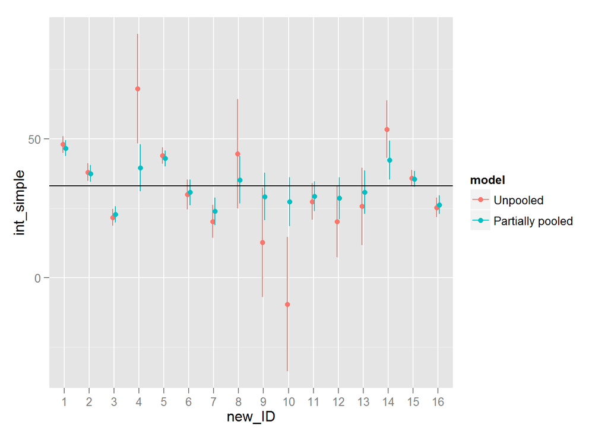

```r
fit_simple1 <- lm(diff ~ 1, data = natsap_tidy)
fit_simple2 <- lm(diff ~ new_ID - 1, data = natsap_tidy)
fit_simple3 <- lmer(diff ~ (1|new_ID), data = natsap_tidy)

## Extract coeffiencts and st errors
int_simple1 <- summary(fit_simple1)$coef[,1]
int_simple2 <- data.frame(int_simple = summary(fit_simple2)$coef[,1])
se_int_simple2 <- data.frame(se_int_simple = summary(fit_simple2)$coef[,2])
int_simple3 <-
    data.frame(int_simple =
               unname(fixef(fit_simple3)) + ranef(fit_simple3)$new_ID[,1])
se_int_simple3 <-
    data.frame(se_int_simple =
               se.ranef(fit_simple3)$new_ID[,1])
int_simple_a <-
    cbind(new_ID = as.factor(dose_tidy$new_ID),
          model = rep("Unpooled", length(int_simple2)),
          int_simple = int_simple2,
          se_int_simple = se_int_simple2)
rownames(int_simple_a) <- NULL
int_simple_b <-
    cbind(new_ID = as.factor(dose_tidy$new_ID),
          model = rep("Partially pooled", length(int_simple3)),
          int_simple = int_simple3,
          se_int_simple = se_int_simple3)
int_simple <- rbind(int_simple_a, int_simple_b)
limits_simple <- aes(ymax = int_simple + se_int_simple,
    ymin = int_simple - se_int_simple)
ggplot(int_simple, aes(x = new_ID, y = int_simple, color = model)) +
    geom_pointrange(limits_simple, position = position_dodge(width = 0.2)) +
    geom_hline(yintercept = fixef(fit_simple3))
```

Let’s look only at `diff` by `sex`. This is what Gelman and Hill call “complete pooling”.

```r
fit_pooled <- lm(diff ~ sex - 1, data = natsap_tidy)
summary(fit_pooled)
```

```
##
## Call:
## lm(formula = diff ~ sex - 1, data = natsap_tidy)
##
## Residuals:
##      Min       1Q   Median       3Q      Max
## -127.401  -24.164   -2.927   22.599  125.073
##
## Coefficients:
##           Estimate Std. Error t value Pr(>|t|)
## sexMale     27.927      1.629   17.14   <2e-16 ***
## sexFemale   42.401      1.700   24.93   <2e-16 ***
## ---
## Signif. codes:  0 '***' 0.001 '**' 0.01 '*' 0.05 '.' 0.1 ' ' 1
##
## Residual standard error: 34.56 on 861 degrees of freedom
## Multiple R-squared:  0.5154, Adjusted R-squared:  0.5142
## F-statistic: 457.8 on 2 and 861 DF,  p-value: < 2.2e-16
```

Contrast this with no pooling.

```r
fit_unpooled <- lm(diff ~ sex + new_ID - 1, data = natsap_tidy)
summary(fit_unpooled)
```

```
##
## Call:
## lm(formula = diff ~ sex + new_ID - 1, data = natsap_tidy)
##
## Residuals:
##     Min      1Q  Median      3Q     Max
## -128.96  -22.54   -2.00   22.32  132.53
##
## Coefficients:
##           Estimate Std. Error t value Pr(>|t|)
## sexMale     39.025      4.649   8.393  < 2e-16 ***
## sexFemale   48.008      3.005  15.977  < 2e-16 ***
## new_ID2     -3.740      4.990  -0.749 0.453803
## new_ID3    -17.275      5.562  -3.106 0.001961 **
## new_ID4     19.992     19.855   1.007 0.314277
## new_ID5     -4.049      4.233  -0.957 0.339031
## new_ID6    -12.643      6.515  -1.940 0.052659 .
## new_ID7    -20.960      7.161  -2.927 0.003512 **
## new_ID8      5.642     20.170   0.280 0.779754
## new_ID9    -35.341     19.855  -1.780 0.075448 .
## new_ID10   -57.508     24.225  -2.374 0.017823 *
## new_ID11   -11.580      8.026  -1.443 0.149448
## new_ID12   -21.305     13.437  -1.586 0.113197
## new_ID13   -13.358     14.636  -0.913 0.361687
## new_ID14    12.797     11.069   1.156 0.247956
## new_ID15    -5.420      4.977  -1.089 0.276467
## new_ID16   -18.553      4.914  -3.776 0.000171 ***
## ---
## Signif. codes:  0 '***' 0.001 '**' 0.01 '*' 0.05 '.' 0.1 ' ' 1
##
## Residual standard error: 33.99 on 846 degrees of freedom
## Multiple R-squared:  0.5392, Adjusted R-squared:  0.5299
## F-statistic: 58.23 on 17 and 846 DF,  p-value: < 2.2e-16
```

We use `lmer` from the `lme4` package to create a varying intercept model.

```r
fit_vint <- lmer(diff ~ sex + (1 | new_ID), data = natsap_tidy)
summary(fit_vint)
```

```
## Linear mixed model fit by REML ['lmerMod']
## Formula: diff ~ sex + (1 | new_ID)
##    Data: natsap_tidy
##
## REML criterion at convergence: 8543.9
##
## Scaled residuals:
##     Min      1Q  Median      3Q     Max
## -3.7631 -0.6638 -0.0647  0.6633  3.8548
##
## Random effects:
##  Groups   Name        Variance Std.Dev.
##  new_ID   (Intercept)   47.93   6.923
##  Residual             1160.66  34.068
## Number of obs: 863, groups:  new_ID, 16
##
## Fixed effects:
##             Estimate Std. Error t value
## (Intercept)   28.908      2.815  10.268
## sexFemale     10.251      3.147   3.257
##
## Correlation of Fixed Effects:
##           (Intr)
## sexFemale -0.480
```

```r
coef(fit_vint)
```

```
## $new_ID
##    (Intercept) sexFemale
## 1     36.34895  10.25091
## 2     33.87791  10.25091
## 3     22.91950  10.25091
## 4     32.08647  10.25091
## 5     32.95377  10.25091
## 6     27.01840  10.25091
## 7     22.47676  10.25091
## 8     30.64451  10.25091
## 9     25.98757  10.25091
## 10    25.19569  10.25091
## 11    28.13625  10.25091
## 12    26.31753  10.25091
## 13    28.26403  10.25091
## 14    35.99240  10.25091
## 15    32.62698  10.25091
## 16    21.67361  10.25091
##
## attr(,"class")
## [1] "coef.mer"
```

```r
fixef(fit_vint)
```

```
## (Intercept)   sexFemale
##    28.90752    10.25091
```

```r
ranef(fit_vint)
```

```
## $new_ID
##    (Intercept)
## 1    7.4414340
## 2    4.9703946
## 3   -5.9880203
## 4    3.1789487
## 5    4.0462530
## 6   -1.8891183
## 7   -6.4307621
## 8    1.7369903
## 9   -2.9199515
## 10  -3.7118311
## 11  -0.7712724
## 12  -2.5899934
## 13  -0.6434942
## 14   7.0848797
## 15   3.7194570
## 16  -7.2339141
```

## Hierarchical models

Now we add a group-level predictor.

```r
## We need to grab the minutes of individual and group therapy for each individual
## as well as the value of RTC_OBH
IT_full <- IT_cent[natsap_tidy$new_ID,]
GT_full <- GT_cent[natsap_tidy$new_ID,]
RFT_full <- RFT_cent[natsap_tidy$new_ID,]
RTC_OBH_full <- RTC_OBH[natsap_tidy$new_ID,]


## The model for individual therapy
fit_hier_vint_IT <- lmer(diff ~ sex + IT_full + (1 | new_ID),
    data = natsap_tidy)
summary(fit_hier_vint_IT)
```

```
## Linear mixed model fit by REML ['lmerMod']
## Formula: diff ~ sex + IT_full + (1 | new_ID)
##    Data: natsap_tidy
##
## REML criterion at convergence: 8543
##
## Scaled residuals:
##     Min      1Q  Median      3Q     Max
## -3.7689 -0.6642 -0.0800  0.6597  3.8790
##
## Random effects:
##  Groups   Name        Variance Std.Dev.
##  new_ID   (Intercept)   41.38   6.433
##  Residual             1158.80  34.041
## Number of obs: 863, groups:  new_ID, 16
##
## Fixed effects:
##             Estimate Std. Error t value
## (Intercept)  28.8168     2.7063  10.648
## sexFemale     9.8440     3.1264   3.149
## IT_full       0.2101     0.1136   1.849
##
## Correlation of Fixed Effects:
##           (Intr) sexFml
## sexFemale -0.493
## IT_full   -0.010 -0.104
```

```r
coef(fit_hier_vint_IT)
```

```
## $new_ID
##    (Intercept) sexFemale   IT_full
## 1     30.02250   9.84404 0.2100665
## 2     37.65191   9.84404 0.2100665
## 3     21.76668   9.84404 0.2100665
## 4     32.11309   9.84404 0.2100665
## 5     31.87925   9.84404 0.2100665
## 6     29.96208   9.84404 0.2100665
## 7     22.03529   9.84404 0.2100665
## 8     29.58824   9.84404 0.2100665
## 9     26.14911   9.84404 0.2100665
## 10    25.92156   9.84404 0.2100665
## 11    27.36978   9.84404 0.2100665
## 12    27.49352   9.84404 0.2100665
## 13    29.09496   9.84404 0.2100665
## 14    33.03883   9.84404 0.2100665
## 15    31.30255   9.84404 0.2100665
## 16    25.67971   9.84404 0.2100665
##
## attr(,"class")
## [1] "coef.mer"
```

```r
fixef(fit_hier_vint_IT)
```

```
## (Intercept)   sexFemale     IT_full
##  28.8168168   9.8440396   0.2100665
```

```r
ranef(fit_hier_vint_IT)
```

```
## $new_ID
##    (Intercept)
## 1    1.2056835
## 2    8.8350894
## 3   -7.0501332
## 4    3.2962695
## 5    3.0624292
## 6    1.1452673
## 7   -6.7815226
## 8    0.7714235
## 9   -2.6677063
## 10  -2.8952561
## 11  -1.4470364
## 12  -1.3232937
## 13   0.2781475
## 14   4.2220106
## 15   2.4857339
## 16  -3.1371062
```

```r
## The model for group therapy
fit_hier_vint_GT <- lmer(diff ~ sex + GT_full + (1 | new_ID),
    data = natsap_tidy)
summary(fit_hier_vint_GT)
```

```
## Linear mixed model fit by REML ['lmerMod']
## Formula: diff ~ sex + GT_full + (1 | new_ID)
##    Data: natsap_tidy
##
## REML criterion at convergence: 8549.6
##
## Scaled residuals:
##     Min      1Q  Median      3Q     Max
## -3.7945 -0.6550 -0.0777  0.6561  3.8525
##
## Random effects:
##  Groups   Name        Variance Std.Dev.
##  new_ID   (Intercept)   47.67   6.904
##  Residual             1160.05  34.060
## Number of obs: 863, groups:  new_ID, 16
##
## Fixed effects:
##             Estimate Std. Error t value
## (Intercept) 29.57158    2.86324  10.328
## sexFemale    9.17485    3.26793   2.808
## GT_full      0.01301    0.01067   1.219
##
## Correlation of Fixed Effects:
##           (Intr) sexFml
## sexFemale -0.506
## GT_full    0.191 -0.272
```

```r
coef(fit_hier_vint_GT)
```

```
## $new_ID
##    (Intercept) sexFemale    GT_full
## 1     35.73433  9.174851 0.01300868
## 2     37.19150  9.174851 0.01300868
## 3     23.37986  9.174851 0.01300868
## 4     32.78462  9.174851 0.01300868
## 5     28.06531  9.174851 0.01300868
## 6     28.76903  9.174851 0.01300868
## 7     24.28378  9.174851 0.01300868
## 8     31.35931  9.174851 0.01300868
## 9     26.71219  9.174851 0.01300868
## 10    25.82070  9.174851 0.01300868
## 11    29.49193  9.174851 0.01300868
## 12    27.17871  9.174851 0.01300868
## 13    27.95504  9.174851 0.01300868
## 14    35.64406  9.174851 0.01300868
## 15    34.62243  9.174851 0.01300868
## 16    24.15242  9.174851 0.01300868
##
## attr(,"class")
## [1] "coef.mer"
```

```r
fixef(fit_hier_vint_GT)
```

```
## (Intercept)   sexFemale     GT_full
## 29.57157518  9.17485096  0.01300868
```

```r
ranef(fit_hier_vint_GT)
```

```
## $new_ID
##    (Intercept)
## 1   6.16275086
## 2   7.61992062
## 3  -6.19171601
## 4   3.21304313
## 5  -1.50626568
## 6  -0.80254248
## 7  -5.28779125
## 8   1.78773763
## 9  -2.85938662
## 10 -3.75087803
## 11 -0.07964723
## 12 -2.39286836
## 13 -1.61653492
## 14  6.07248049
## 15  5.05085118
## 16 -5.41915332
```

```r
## The model for remote family therapy
fit_hier_vint_RFT <- lmer(diff ~ sex + RFT_full + (1 | new_ID),
    data = natsap_tidy)
summary(fit_hier_vint_RFT)
```

```
## Linear mixed model fit by REML ['lmerMod']
## Formula: diff ~ sex + RFT_full + (1 | new_ID)
##    Data: natsap_tidy
##
## REML criterion at convergence: 8547.1
##
## Scaled residuals:
##     Min      1Q  Median      3Q     Max
## -3.7728 -0.6618 -0.0680  0.6538  3.8622
##
## Random effects:
##  Groups   Name        Variance Std.Dev.
##  new_ID   (Intercept)   54.04   7.351
##  Residual             1160.03  34.059
## Number of obs: 863, groups:  new_ID, 16
##
## Fixed effects:
##             Estimate Std. Error t value
## (Intercept) 29.47212    2.98743   9.865
## sexFemale    9.50996    3.26008   2.917
## RFT_full     0.04741    0.05983   0.792
##
## Correlation of Fixed Effects:
##           (Intr) sexFml
## sexFemale -0.494
## RFT_full   0.226 -0.228
```

```r
coef(fit_hier_vint_RFT)
```

```
## $new_ID
##    (Intercept) sexFemale   RFT_full
## 1     34.49445  9.509962 0.04740947
## 2     36.39307  9.509962 0.04740947
## 3     21.40719  9.509962 0.04740947
## 4     32.81718  9.509962 0.04740947
## 5     32.25082  9.509962 0.04740947
## 6     27.11780  9.509962 0.04740947
## 7     23.76626  9.509962 0.04740947
## 8     31.29651  9.509962 0.04740947
## 9     26.03199  9.509962 0.04740947
## 10    25.31286  9.509962 0.04740947
## 11    29.63198  9.509962 0.04740947
## 12    26.46700  9.509962 0.04740947
## 13    28.57162  9.509962 0.04740947
## 14    36.90486  9.509962 0.04740947
## 15    35.10731  9.509962 0.04740947
## 16    23.98307  9.509962 0.04740947
##
## attr(,"class")
## [1] "coef.mer"
```

```r
fixef(fit_hier_vint_RFT)
```

```
## (Intercept)   sexFemale    RFT_full
## 29.47212272  9.50996248  0.04740947
```

```r
ranef(fit_hier_vint_RFT)
```

```
## $new_ID
##    (Intercept)
## 1    5.0223298
## 2    6.9209480
## 3   -8.0649313
## 4    3.3450607
## 5    2.7786926
## 6   -2.3543228
## 7   -5.7058619
## 8    1.8243909
## 9   -3.4401291
## 10  -4.1592662
## 11   0.1598555
## 12  -3.0051250
## 13  -0.9005036
## 14   7.4327335
## 15   5.6351850
## 16  -5.4890563
```

```r
## The model for RTC_OBH
fit_hier_vint_RTC_OBH <-
    lmer(diff ~ sex + RTC_OBH_full + (1 | new_ID),
    data = natsap_tidy)
summary(fit_hier_vint_RTC_OBH)
```

```
## Linear mixed model fit by REML ['lmerMod']
## Formula: diff ~ sex + RTC_OBH_full + (1 | new_ID)
##    Data: natsap_tidy
##
## REML criterion at convergence: 8538.4
##
## Scaled residuals:
##     Min      1Q  Median      3Q     Max
## -3.7707 -0.6643 -0.0708  0.6585  3.8636
##
## Random effects:
##  Groups   Name        Variance Std.Dev.
##  new_ID   (Intercept)   55.09   7.422
##  Residual             1160.24  34.062
## Number of obs: 863, groups:  new_ID, 16
##
## Fixed effects:
##                 Estimate Std. Error t value
## (Intercept)       27.371      3.966   6.902
## sexFemale          9.779      3.219   3.038
## RTC_OBH_fullRTC    3.091      5.273   0.586
##
## Correlation of Fixed Effects:
##             (Intr) sexFml
## sexFemale   -0.232
## RTC_OBH_RTC -0.675 -0.158
```

```r
coef(fit_hier_vint_RTC_OBH)
```

```
## $new_ID
##    (Intercept) sexFemale RTC_OBH_fullRTC
## 1     34.04058  9.779137        3.090692
## 2     33.88019  9.779137        3.090692
## 3     19.92421  9.779137        3.090692
## 4     30.83223  9.779137        3.090692
## 5     30.57035  9.779137        3.090692
## 6     24.48985  9.779137        3.090692
## 7     21.57263  9.779137        3.090692
## 8     29.14231  9.779137        3.090692
## 9     23.93332  9.779137        3.090692
## 10    23.05755  9.779137        3.090692
## 11    27.41238  9.779137        3.090692
## 12    24.13584  9.779137        3.090692
## 13    26.30809  9.779137        3.090692
## 14    34.64973  9.779137        3.090692
## 15    32.59463  9.779137        3.090692
## 16    21.39657  9.779137        3.090692
##
## attr(,"class")
## [1] "coef.mer"
```

```r
fixef(fit_hier_vint_RTC_OBH)
```

```
##     (Intercept)       sexFemale RTC_OBH_fullRTC
##       27.371280        9.779137        3.090692
```

```r
ranef(fit_hier_vint_RTC_OBH)
```

```
## $new_ID
##    (Intercept)
## 1   6.66930227
## 2   6.50890624
## 3  -7.44706594
## 4   3.46095417
## 5   3.19907154
## 6  -2.88142799
## 7  -5.79865148
## 8   1.77102889
## 9  -3.43795740
## 10 -4.31372934
## 11  0.04110205
## 12 -3.23543706
## 13 -1.06319122
## 14  7.27845209
## 15  5.22335270
## 16 -5.97470951
```

We realize that we need to control not only for `sex`, but also for `RTC_OBH`. There appears to be a bigger difference for females in RTC programs (because of the much higher admission scores).

```r
## The model for individual therapy
fit_hier_vint_IT2 <- lmer(diff ~ sex + RTC_OBH_full + IT_full + (1 | new_ID),
    data = natsap_tidy)
summary(fit_hier_vint_IT2)
```

```
## Linear mixed model fit by REML ['lmerMod']
## Formula: diff ~ sex + RTC_OBH_full + IT_full + (1 | new_ID)
##    Data: natsap_tidy
##
## REML criterion at convergence: 8537.9
##
## Scaled residuals:
##     Min      1Q  Median      3Q     Max
## -3.7714 -0.6647 -0.0751  0.6619  3.8813
##
## Random effects:
##  Groups   Name        Variance Std.Dev.
##  new_ID   (Intercept)   49.05   7.004
##  Residual             1158.79  34.041
## Number of obs: 863, groups:  new_ID, 16
##
## Fixed effects:
##                 Estimate Std. Error t value
## (Intercept)      28.7548     3.8892   7.393
## sexFemale         9.6823     3.1964   3.029
## RTC_OBH_fullRTC   0.1591     5.3460   0.030
## IT_full           0.2137     0.1264   1.691
##
## Correlation of Fixed Effects:
##             (Intr) sexFml RTC_OB
## sexFemale   -0.244
## RTC_OBH_RTC -0.685 -0.143
## IT_full      0.208 -0.041 -0.319
```

```r
coef(fit_hier_vint_IT2)
```

```
## $new_ID
##    (Intercept) sexFemale RTC_OBH_fullRTC  IT_full
## 1     29.93405  9.682274       0.1591422 0.213725
## 2     38.02445  9.682274       0.1591422 0.213725
## 3     21.39089  9.682274       0.1591422 0.213725
## 4     32.60977  9.682274       0.1591422 0.213725
## 5     31.93600  9.682274       0.1591422 0.213725
## 6     30.01025  9.682274       0.1591422 0.213725
## 7     21.49180  9.682274       0.1591422 0.213725
## 8     29.62668  9.682274       0.1591422 0.213725
## 9     25.65248  9.682274       0.1591422 0.213725
## 10    25.37619  9.682274       0.1591422 0.213725
## 11    27.20102  9.682274       0.1591422 0.213725
## 12    27.24944  9.682274       0.1591422 0.213725
## 13    29.07104  9.682274       0.1591422 0.213725
## 14    33.44568  9.682274       0.1591422 0.213725
## 15    31.37224  9.682274       0.1591422 0.213725
## 16    25.68434  9.682274       0.1591422 0.213725
##
## attr(,"class")
## [1] "coef.mer"
```

```r
fixef(fit_hier_vint_IT2)
```

```
##     (Intercept)       sexFemale RTC_OBH_fullRTC         IT_full
##      28.7547703       9.6822740       0.1591422       0.2137250
```

```r
ranef(fit_hier_vint_IT2)
```

```
## $new_ID
##    (Intercept)
## 1    1.1792808
## 2    9.2696830
## 3   -7.3638769
## 4    3.8550008
## 5    3.1812319
## 6    1.2554835
## 7   -7.2629654
## 8    0.8719076
## 9   -3.1022946
## 10  -3.3785786
## 11  -1.5537526
## 12  -1.5053334
## 13   0.3162710
## 14   4.6909079
## 15   2.6174652
## 16  -3.0704301
```

```r
## The model for group therapy
fit_hier_vint_GT2 <- lmer(diff ~ sex + RTC_OBH_full + GT_full + (1 | new_ID),
    data = natsap_tidy)
summary(fit_hier_vint_GT2)
```

```
## Linear mixed model fit by REML ['lmerMod']
## Formula: diff ~ sex + RTC_OBH_full + GT_full + (1 | new_ID)
##    Data: natsap_tidy
##
## REML criterion at convergence: 8543.9
##
## Scaled residuals:
##     Min      1Q  Median      3Q     Max
## -3.7958 -0.6559 -0.0792  0.6593  3.8534
##
## Random effects:
##  Groups   Name        Variance Std.Dev.
##  new_ID   (Intercept)   55.77   7.468
##  Residual             1160.01  34.059
## Number of obs: 863, groups:  new_ID, 16
##
## Fixed effects:
##                 Estimate Std. Error t value
## (Intercept)     30.54693    5.01392   6.092
## sexFemale        9.06637    3.28998   2.756
## RTC_OBH_fullRTC -1.70856    7.01676  -0.243
## GT_full          0.01560    0.01495   1.044
##
## Correlation of Fixed Effects:
##             (Intr) sexFml RTC_OB
## sexFemale   -0.303
## RTC_OBH_RTC -0.804  0.018
## GT_full      0.607 -0.204 -0.656
```

```r
coef(fit_hier_vint_GT2)
```

```
## $new_ID
##    (Intercept) sexFemale RTC_OBH_fullRTC    GT_full
## 1     37.25036  9.066369       -1.708556 0.01559743
## 2     38.15834  9.066369       -1.708556 0.01559743
## 3     24.90250  9.066369       -1.708556 0.01559743
## 4     34.34424  9.066369       -1.708556 0.01559743
## 5     28.52999  9.066369       -1.708556 0.01559743
## 6     30.46728  9.066369       -1.708556 0.01559743
## 7     24.61812  9.066369       -1.708556 0.01559743
## 8     32.72278  9.066369       -1.708556 0.01559743
## 9     27.36926  9.066369       -1.708556 0.01559743
## 10    26.26792  9.066369       -1.708556 0.01559743
## 11    30.13253  9.066369       -1.708556 0.01559743
## 12    28.10190  9.066369       -1.708556 0.01559743
## 13    28.69100  9.066369       -1.708556 0.01559743
## 14    37.36898  9.066369       -1.708556 0.01559743
## 15    35.23097  9.066369       -1.708556 0.01559743
## 16    24.59468  9.066369       -1.708556 0.01559743
##
## attr(,"class")
## [1] "coef.mer"
```

```r
fixef(fit_hier_vint_GT2)
```

```
##     (Intercept)       sexFemale RTC_OBH_fullRTC         GT_full
##     30.54692875      9.06636944     -1.70855647      0.01559743
```

```r
ranef(fit_hier_vint_GT2)
```

```
## $new_ID
##    (Intercept)
## 1   6.70342829
## 2   7.61140738
## 3  -5.64442703
## 4   3.79731183
## 5  -2.01693742
## 6  -0.07964537
## 7  -5.92880429
## 8   2.17585567
## 9  -3.17767189
## 10 -4.27900706
## 11 -0.41439580
## 12 -2.44503099
## 13 -1.85592950
## 14  6.82205346
## 15  4.68404159
## 16 -5.95224887
```

```r
## The model for remote family therapy
fit_hier_vint_RFT2 <- lmer(diff ~ sex + RTC_OBH_full + RFT_full + (1 | new_ID),
    data = natsap_tidy)
summary(fit_hier_vint_RFT2)
```

```
## Linear mixed model fit by REML ['lmerMod']
## Formula: diff ~ sex + RTC_OBH_full + RFT_full + (1 | new_ID)
##    Data: natsap_tidy
##
## REML criterion at convergence: 8539.8
##
## Scaled residuals:
##     Min      1Q  Median      3Q     Max
## -3.7734 -0.6612 -0.0742  0.6592  3.8601
##
## Random effects:
##  Groups   Name        Variance Std.Dev.
##  new_ID   (Intercept)   60.78   7.796
##  Residual             1160.16  34.061
## Number of obs: 863, groups:  new_ID, 16
##
## Fixed effects:
##                 Estimate Std. Error t value
## (Intercept)      32.9732     9.6968   3.400
## sexFemale         9.2231     3.3152   2.782
## RTC_OBH_fullRTC  -5.5490    14.6197  -0.380
## RFT_full          0.1072     0.1676   0.640
##
## Correlation of Fixed Effects:
##             (Intr) sexFml RTC_OB
## sexFemale   -0.287
## RTC_OBH_RTC -0.948  0.144
## RFT_full     0.906 -0.215 -0.928
```

```r
coef(fit_hier_vint_RFT2)
```

```
## $new_ID
##    (Intercept) sexFemale RTC_OBH_fullRTC  RFT_full
## 1     36.63860  9.223071       -5.548998 0.1072105
## 2     39.82070  9.223071       -5.548998 0.1072105
## 3     24.64814  9.223071       -5.548998 0.1072105
## 4     36.69775  9.223071       -5.548998 0.1072105
## 5     35.91955  9.223071       -5.548998 0.1072105
## 6     31.71783  9.223071       -5.548998 0.1072105
## 7     26.52520  9.223071       -5.548998 0.1072105
## 8     35.21802  9.223071       -5.548998 0.1072105
## 9     29.18181  9.223071       -5.548998 0.1072105
## 10    28.52834  9.223071       -5.548998 0.1072105
## 11    32.80065  9.223071       -5.548998 0.1072105
## 12    30.15845  9.223071       -5.548998 0.1072105
## 13    32.38163  9.223071       -5.548998 0.1072105
## 14    41.61540  9.223071       -5.548998 0.1072105
## 15    38.48314  9.223071       -5.548998 0.1072105
## 16    27.23646  9.223071       -5.548998 0.1072105
##
## attr(,"class")
## [1] "coef.mer"
```

```r
fixef(fit_hier_vint_RFT2)
```

```
##     (Intercept)       sexFemale RTC_OBH_fullRTC        RFT_full
##      32.9732291       9.2230711      -5.5489984       0.1072105
```

```r
ranef(fit_hier_vint_RFT2)
```

```
## $new_ID
##    (Intercept)
## 1    3.6653671
## 2    6.8474677
## 3   -8.3250909
## 4    3.7245239
## 5    2.9463201
## 6   -1.2553985
## 7   -6.4480288
## 8    2.2447956
## 9   -3.7914195
## 10  -4.4448844
## 11  -0.1725753
## 12  -2.8147832
## 13  -0.5916028
## 14   8.6421725
## 15   5.5099104
## 16  -5.7367741
```

Let’s try to plot something.

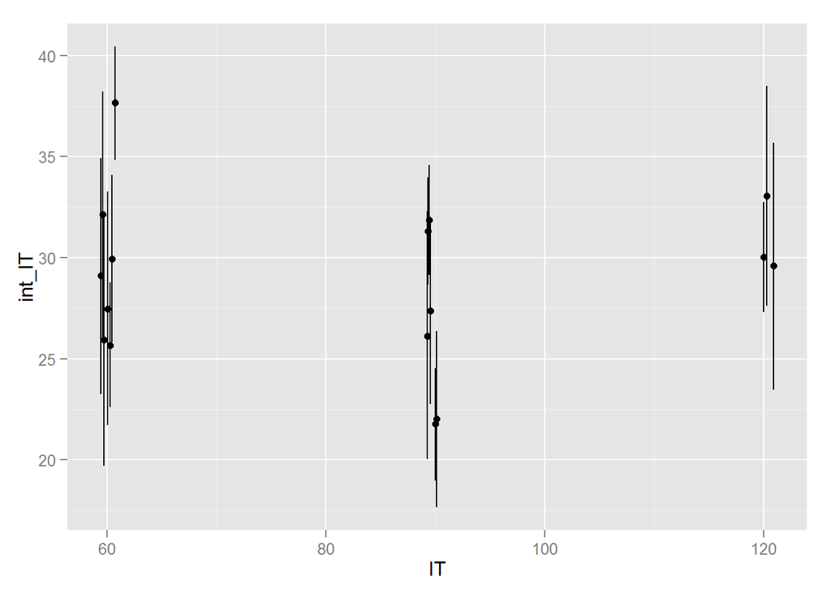

```r
## Extract coefficients for minutes of individual therapy
int_IT <-coef(fit_hier_vint_IT)$new_ID[,1]
se_int_IT <- se.ranef(fit_hier_vint_IT)$new_ID[,1]
int_by_IT <-
    data.frame(dose_tidy$new_ID, IT, int_IT, se_int_IT)
limits_ind <- aes(ymax = int_IT + se_int_IT, ymin = int_IT - se_int_IT)
ggplot(int_by_IT, aes(x = IT, y = int_IT)) +
    geom_pointrange(limits_ind, position = position_jitter(width = 1))
```

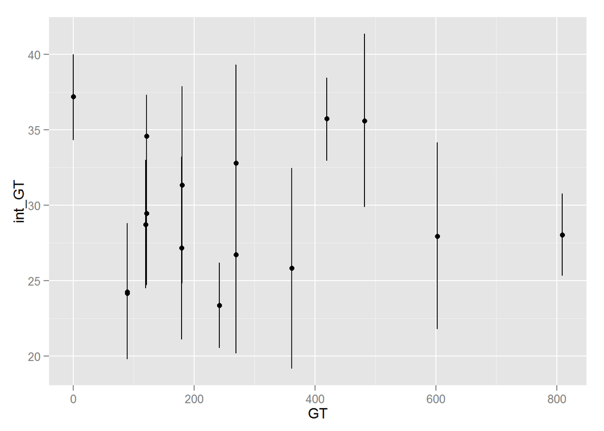

```r
## Extract coefficients for minutes of group therapy
int_GT <-coef(fit_hier_vint_GT)$new_ID[,1]
se_int_GT <- se.ranef(fit_hier_vint_GT)$new_ID[,1]
int_by_GT <-
    data.frame(dose_tidy$new_ID, GT,int_GT, se_int_GT)
limits_group <- aes(ymax = int_GT + se_int_GT, ymin = int_GT - se_int_GT)
ggplot(int_by_GT, aes(x = GT, y = int_GT)) +
    geom_pointrange(limits_group, position = position_jitter(width = 2))
```

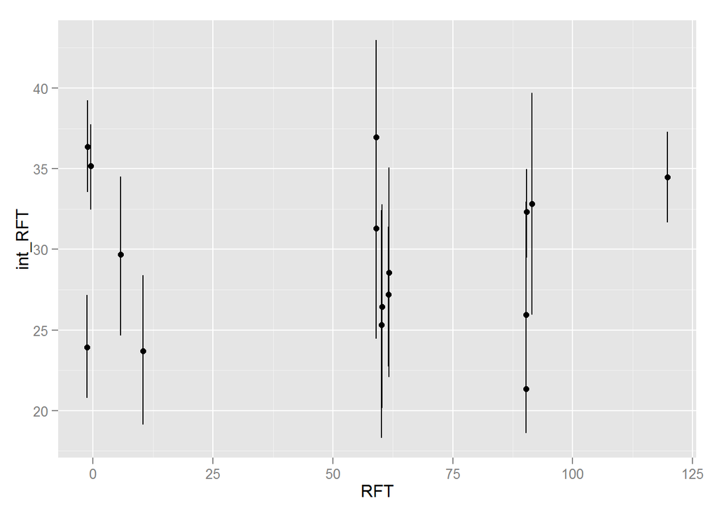

```r
## Extract coefficients for minutes of remote family therapy
int_RFT <-coef(fit_hier_vint_RFT)$new_ID[,1]
se_int_RFT <- se.ranef(fit_hier_vint_RFT)$new_ID[,1]
int_by_RFT <-
    data.frame(dose_tidy$new_ID, RFT,int_RFT, se_int_RFT)
limits_RFT <- aes(ymax = int_RFT + se_int_RFT, ymin = int_RFT - se_int_RFT)
ggplot(int_by_RFT, aes(x = RFT, y = int_RFT)) +
    geom_pointrange(limits_RFT, position = position_jitter(width = 2))
```

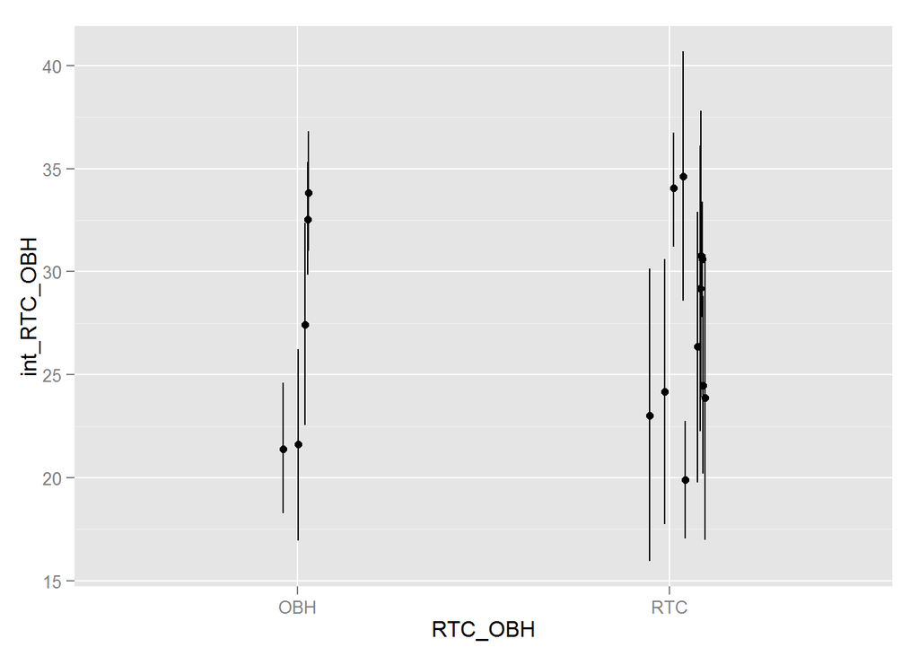

```r
## Extract coefficients for RTC_OBH
int_RTC_OBH <-coef(fit_hier_vint_RTC_OBH)$new_ID[,1]
se_int_RTC_OBH <- se.ranef(fit_hier_vint_RTC_OBH)$new_ID[,1]
int_by_RTC_OBH <-
    data.frame(dose_tidy$new_ID, RTC_OBH,int_RTC_OBH, se_int_RTC_OBH)
limits_RTC_OBH <- aes(ymax = int_RTC_OBH + se_int_RTC_OBH,
    ymin = int_RTC_OBH - se_int_RTC_OBH)
ggplot(int_by_RTC_OBH, aes(x = RTC_OBH, y = int_RTC_OBH)) +
    geom_pointrange(limits_RTC_OBH, position = position_jitter(width = 0.1))
```

Repeat for the models controling for both `sex` and `RTC_OBH`.

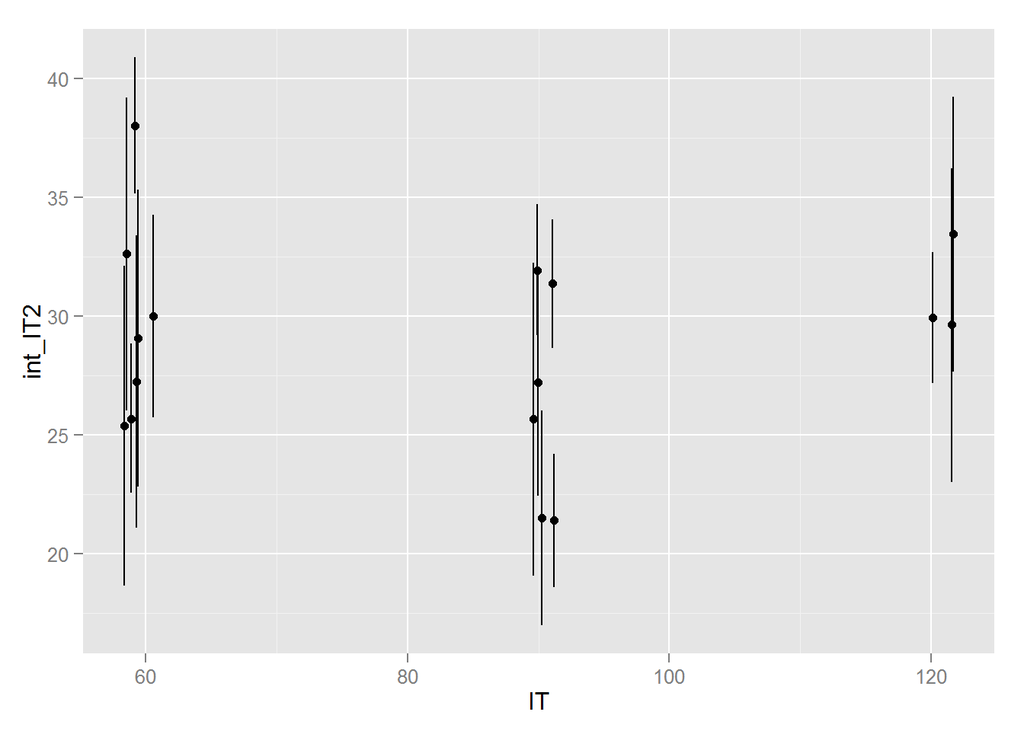

```r
## Extract coefficients for minutes of individual therapy
int_IT2 <-coef(fit_hier_vint_IT2)$new_ID[,1]
se_int_IT2 <- se.ranef(fit_hier_vint_IT2)$new_ID[,1]
int_by_IT2 <-
    data.frame(dose_tidy$new_ID, IT, int_IT2, se_int_IT2)
limits_ind2 <- aes(ymax = int_IT2 + se_int_IT2, ymin = int_IT2 - se_int_IT2)
plot_IT2 <- ggplot(int_by_IT2, aes(x = IT, y = int_IT2)) +
    geom_pointrange(limits_ind2, position = position_jitter(width = 2))
plot_IT2
```

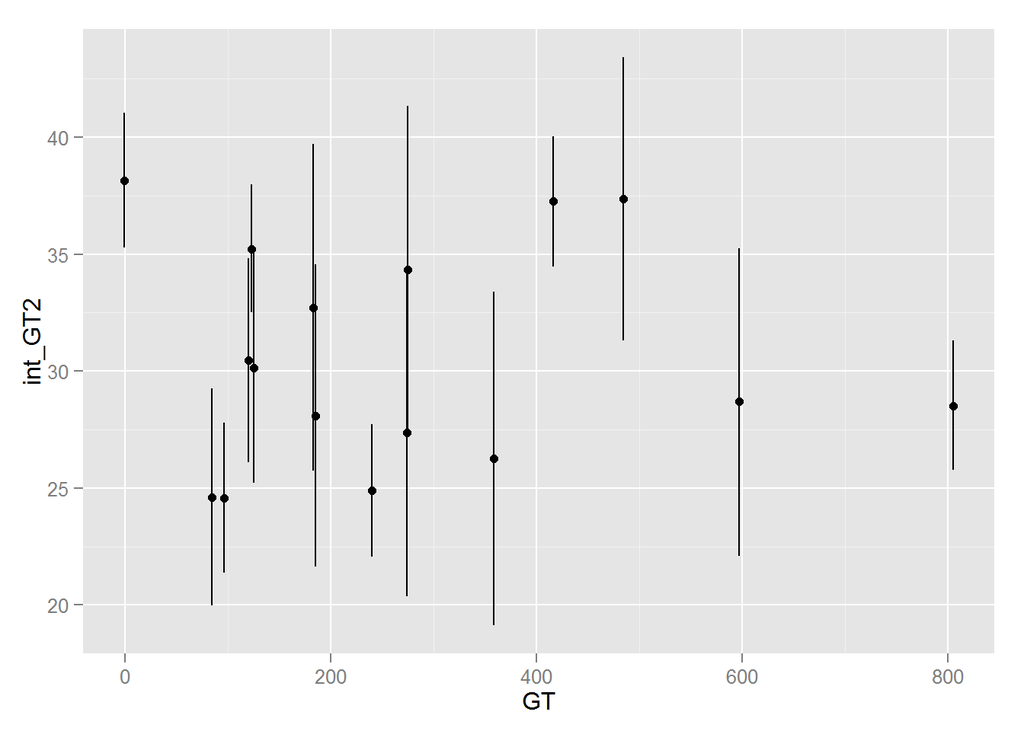

```r
## Extract coefficients for minutes of group therapy
int_GT2 <-coef(fit_hier_vint_GT2)$new_ID[,1]
se_int_GT2 <- se.ranef(fit_hier_vint_GT2)$new_ID[,1]
int_by_GT2 <-
    data.frame(dose_tidy$new_ID, GT,int_GT2, se_int_GT2)
limits_group2 <- aes(ymax = int_GT2 + se_int_GT2, ymin = int_GT2 - se_int_GT2)
plot_GT2 <- ggplot(int_by_GT2, aes(x = GT, y = int_GT2)) +
    geom_pointrange(limits_group2, position = position_jitter(width = 8))
plot_GT2
```

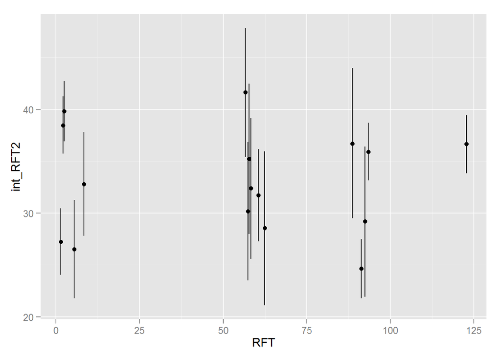

```r
## Extract coefficients for minutes of remote family therapy
int_RFT2 <-coef(fit_hier_vint_RFT2)$new_ID[,1]
se_int_RFT2 <- se.ranef(fit_hier_vint_RFT2)$new_ID[,1]
int_by_RFT2 <-
    data.frame(dose_tidy$new_ID, RFT,int_RFT2, se_int_RFT2)
limits_RFT2 <- aes(ymax = int_RFT2 + se_int_RFT2, ymin = int_RFT2 - se_int_RFT2)
plot_RFT2 <- ggplot(int_by_RFT2, aes(x = RFT, y = int_RFT2)) +
    geom_pointrange(limits_RFT2, position = position_jitter(width = 4))
plot_RFT2
```

What if we didn’t look at `diff`? Since all outcomes seem to be roughly the same, what if we only look at `discharge_OQ`?

```r
## The model for individual therapy
fit_hier_vint_IT3 <- lmer(discharge_OQ ~ sex + RTC_OBH_full + IT_full + (1 | new_ID),
    data = natsap_tidy)
summary(fit_hier_vint_IT3)
```

```
## Linear mixed model fit by REML ['lmerMod']
## Formula: discharge_OQ ~ sex + RTC_OBH_full + IT_full + (1 | new_ID)
##    Data: natsap_tidy
##
## REML criterion at convergence: 8080.2
##
## Scaled residuals:
##     Min      1Q  Median      3Q     Max
## -2.2333 -0.6977 -0.0839  0.5581  4.9700
##
## Random effects:
##  Groups   Name        Variance Std.Dev.
##  new_ID   (Intercept)  82.81    9.10
##  Residual             674.33   25.97
## Number of obs: 863, groups:  new_ID, 16
##
## Fixed effects:
##                 Estimate Std. Error t value
## (Intercept)      40.0343     4.4688   8.959
## sexFemale         0.1966     2.5694   0.077
## RTC_OBH_fullRTC  -6.9059     5.9172  -1.167
## IT_full          -0.1574     0.1355  -1.162
##
## Correlation of Fixed Effects:
##             (Intr) sexFml RTC_OB
## sexFemale   -0.160
## RTC_OBH_RTC -0.739 -0.105
## IT_full      0.160 -0.007 -0.246
```

```r
coef(fit_hier_vint_IT3)
```

```
## $new_ID
##    (Intercept) sexFemale RTC_OBH_fullRTC    IT_full
## 1     38.94092 0.1965872        -6.90589 -0.1574466
## 2     25.43860 0.1965872        -6.90589 -0.1574466
## 3     33.20460 0.1965872        -6.90589 -0.1574466
## 4     35.49311 0.1965872        -6.90589 -0.1574466
## 5     40.83097 0.1965872        -6.90589 -0.1574466
## 6     47.01385 0.1965872        -6.90589 -0.1574466
## 7     48.28027 0.1965872        -6.90589 -0.1574466
## 8     41.23037 0.1965872        -6.90589 -0.1574466
## 9     33.98276 0.1965872        -6.90589 -0.1574466
## 10    46.07445 0.1965872        -6.90589 -0.1574466
## 11    45.38265 0.1965872        -6.90589 -0.1574466
## 12    40.75479 0.1965872        -6.90589 -0.1574466
## 13    39.46684 0.1965872        -6.90589 -0.1574466
## 14    43.38494 0.1965872        -6.90589 -0.1574466
## 15    31.61822 0.1965872        -6.90589 -0.1574466
## 16    49.45190 0.1965872        -6.90589 -0.1574466
##
## attr(,"class")
## [1] "coef.mer"
```

```r
fixef(fit_hier_vint_IT3)
```

```
##     (Intercept)       sexFemale RTC_OBH_fullRTC         IT_full
##      40.0343273       0.1965872      -6.9058901      -0.1574466
```

```r
ranef(fit_hier_vint_IT3)
```

```
## $new_ID
##    (Intercept)
## 1   -1.0934043
## 2  -14.5957273
## 3   -6.8297298
## 4   -4.5412195
## 5    0.7966452
## 6    6.9795254
## 7    8.2459398
## 8    1.1960385
## 9   -6.0515698
## 10   6.0401233
## 11   5.3483257
## 12   0.7204607
## 13  -0.5674842
## 14   3.3506146
## 15  -8.4161085
## 16   9.4175704
```

```r
## The model for group therapy
fit_hier_vint_GT3 <- lmer(discharge_OQ ~ sex + RTC_OBH_full + GT_full + (1 | new_ID),
    data = natsap_tidy)
summary(fit_hier_vint_GT3)
```

```
## Linear mixed model fit by REML ['lmerMod']
## Formula: discharge_OQ ~ sex + RTC_OBH_full + GT_full + (1 | new_ID)
##    Data: natsap_tidy
##
## REML criterion at convergence: 8085.8
##
## Scaled residuals:
##     Min      1Q  Median      3Q     Max
## -2.2304 -0.7219 -0.0802  0.5468  4.9692
##
## Random effects:
##  Groups   Name        Variance Std.Dev.
##  new_ID   (Intercept)  95.92    9.794
##  Residual             674.38   25.969
## Number of obs: 863, groups:  new_ID, 16
##
## Fixed effects:
##                  Estimate Std. Error t value
## (Intercept)     40.844469   5.761125   7.090
## sexFemale        0.177376   2.599534   0.068
## RTC_OBH_fullRTC -8.487566   7.939899  -1.069
## GT_full         -0.000407   0.017173  -0.024
##
## Correlation of Fixed Effects:
##             (Intr) sexFml RTC_OB
## sexFemale   -0.188
## RTC_OBH_RTC -0.834 -0.006
## GT_full      0.578 -0.113 -0.642
```

```r
coef(fit_hier_vint_GT3)
```

```
## $new_ID
##    (Intercept) sexFemale RTC_OBH_fullRTC       GT_full
## 1     34.95195 0.1773759       -8.487566 -0.0004069945
## 2     28.59875 0.1773759       -8.487566 -0.0004069945
## 3     33.55713 0.1773759       -8.487566 -0.0004069945
## 4     37.09544 0.1773759       -8.487566 -0.0004069945
## 5     41.48527 0.1773759       -8.487566 -0.0004069945
## 6     51.61220 0.1773759       -8.487566 -0.0004069945
## 7     47.62105 0.1773759       -8.487566 -0.0004069945
## 8     40.62685 0.1773759       -8.487566 -0.0004069945
## 9     34.00491 0.1773759       -8.487566 -0.0004069945
## 10    48.59621 0.1773759       -8.487566 -0.0004069945
## 11    44.73891 0.1773759       -8.487566 -0.0004069945
## 12    43.75846 0.1773759       -8.487566 -0.0004069945
## 13    42.27647 0.1773759       -8.487566 -0.0004069945
## 14    41.32427 0.1773759       -8.487566 -0.0004069945
## 15    30.41572 0.1773759       -8.487566 -0.0004069945
## 16    52.84791 0.1773759       -8.487566 -0.0004069945
##
## attr(,"class")
## [1] "coef.mer"
```

```r
fixef(fit_hier_vint_GT3)
```

```
##     (Intercept)       sexFemale RTC_OBH_fullRTC         GT_full
##   40.8444687716    0.1773759467   -8.4875659614   -0.0004069945
```

```r
ranef(fit_hier_vint_GT3)
```

```
## $new_ID
##    (Intercept)
## 1   -5.8925226
## 2  -12.2457167
## 3   -7.2873385
## 4   -3.7490274
## 5    0.6407999
## 6   10.7677343
## 7    6.7765798
## 8   -0.2176219
## 9   -6.8395595
## 10   7.7517444
## 11   3.8944443
## 12   2.9139935
## 13   1.4319988
## 14   0.4797990
## 15 -10.4287455
## 16  12.0034382
```

```r
## The model for remote family therapy
fit_hier_vint_RFT3 <- lmer(discharge_OQ ~ sex + RTC_OBH_full + RFT_full + (1 | new_ID),
    data = natsap_tidy)
summary(fit_hier_vint_RFT3)
```

```
## Linear mixed model fit by REML ['lmerMod']
## Formula: discharge_OQ ~ sex + RTC_OBH_full + RFT_full + (1 | new_ID)
##    Data: natsap_tidy
##
## REML criterion at convergence: 8078.6
##
## Scaled residuals:
##     Min      1Q  Median      3Q     Max
## -2.2127 -0.7085 -0.0940  0.5458  4.9765
##
## Random effects:
##  Groups   Name        Variance Std.Dev.
##  new_ID   (Intercept)  79.63    8.923
##  Residual             673.69   25.956
## Number of obs: 863, groups:  new_ID, 16
##
## Fixed effects:
##                 Estimate Std. Error t value
## (Intercept)      26.9699     9.7607   2.763
## sexFemale         0.8904     2.6034   0.342
## RTC_OBH_fullRTC  12.3991    14.3818   0.862
## RFT_full         -0.2685     0.1692  -1.587
##
## Correlation of Fixed Effects:
##             (Intr) sexFml RTC_OB
## sexFemale   -0.226
## RTC_OBH_RTC -0.951  0.115
## RFT_full     0.896 -0.172 -0.920
```

```r
coef(fit_hier_vint_RFT3)
```

```
## $new_ID
##    (Intercept) sexFemale RTC_OBH_fullRTC   RFT_full
## 1     30.63139 0.8904212        12.39915 -0.2685313
## 2     14.34859 0.8904212        12.39915 -0.2685313
## 3     22.42924 0.8904212        12.39915 -0.2685313
## 4     24.24482 0.8904212        12.39915 -0.2685313
## 5     29.39270 0.8904212        12.39915 -0.2685313
## 6     32.92780 0.8904212        12.39915 -0.2685313
## 7     34.92949 0.8904212        12.39915 -0.2685313
## 8     25.42308 0.8904212        12.39915 -0.2685313
## 9     21.53988 0.8904212        12.39915 -0.2685313
## 10    32.52104 0.8904212        12.39915 -0.2685313
## 11    31.33637 0.8904212        12.39915 -0.2685313
## 12    27.17616 0.8904212        12.39915 -0.2685313
## 13    26.03946 0.8904212        12.39915 -0.2685313
## 14    24.34334 0.8904212        12.39915 -0.2685313
## 15    16.12141 0.8904212        12.39915 -0.2685313
## 16    38.11364 0.8904212        12.39915 -0.2685313
##
## attr(,"class")
## [1] "coef.mer"
```

```r
fixef(fit_hier_vint_RFT3)
```

```
##     (Intercept)       sexFemale RTC_OBH_fullRTC        RFT_full
##      26.9699007       0.8904212      12.3991472      -0.2685313
```

```r
ranef(fit_hier_vint_RFT3)
```

```
## $new_ID
##    (Intercept)
## 1    3.6614902
## 2  -12.6213116
## 3   -4.5406610
## 4   -2.7250792
## 5    2.4227979
## 6    5.9579006
## 7    7.9595941
## 8   -1.5468179
## 9   -5.4300253
## 10   5.5511404
## 11   4.3664732
## 12   0.2062562
## 13  -0.9304371
## 14  -2.6265647
## 15 -10.8484946
## 16  11.1437390
```

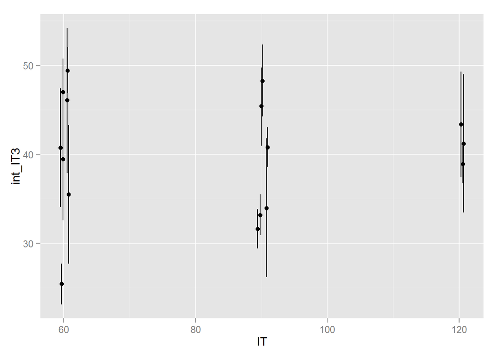

```r
## Extract coefficients for minutes of individual therapy
int_IT3 <-coef(fit_hier_vint_IT3)$new_ID[,1]
se_int_IT3 <- se.ranef(fit_hier_vint_IT3)$new_ID[,1]
int_by_IT3 <-
    data.frame(dose_tidy$new_ID, IT, int_IT3, se_int_IT3)
limits_ind3 <- aes(ymax = int_IT3 + se_int_IT3, ymin = int_IT3 - se_int_IT3)
ggplot(int_by_IT3, aes(x = IT, y = int_IT3)) +
    geom_pointrange(limits_ind3, position = position_jitter(width = 1))
```

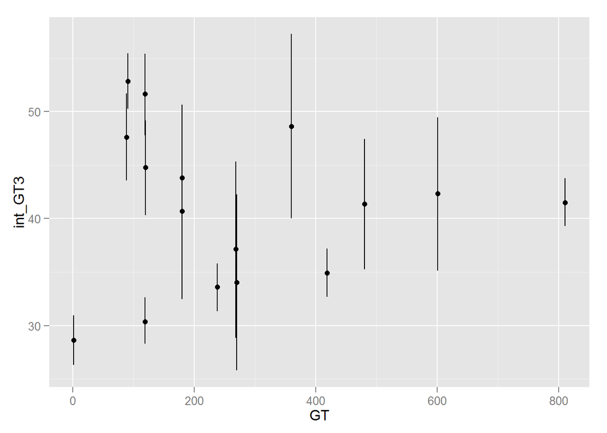

```r
## Extract coefficients for minutes of group therapy
int_GT3 <-coef(fit_hier_vint_GT3)$new_ID[,1]
se_int_GT3 <- se.ranef(fit_hier_vint_GT3)$new_ID[,1]
int_by_GT3 <-
    data.frame(dose_tidy$new_ID, GT,int_GT3, se_int_GT3)
limits_group3 <- aes(ymax = int_GT3 + se_int_GT3, ymin = int_GT3 - se_int_GT3)
ggplot(int_by_GT3, aes(x = GT, y = int_GT3)) +
    geom_pointrange(limits_group3, position = position_jitter(width = 2))
```

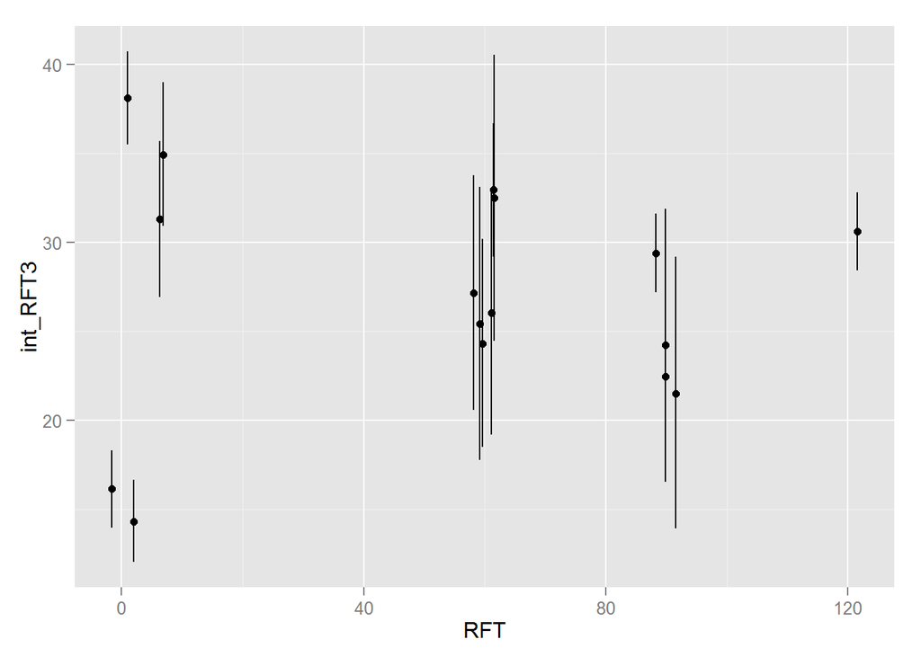

```r
## Extract coefficients for minutes of remote family therapy
int_RFT3 <-coef(fit_hier_vint_RFT3)$new_ID[,1]
se_int_RFT3 <- se.ranef(fit_hier_vint_RFT3)$new_ID[,1]
int_by_RFT3 <-
    data.frame(dose_tidy$new_ID, RFT,int_RFT3, se_int_RFT3)
limits_RFT3 <- aes(ymax = int_RFT3 + se_int_RFT3, ymin = int_RFT3 - se_int_RFT3)
ggplot(int_by_RFT3, aes(x = RFT, y = int_RFT3)) +
    geom_pointrange(limits_RFT3, position = position_jitter(width = 2))
```

# Descriptive Statistics

## Sample sizes

```r
## Sample size check
sample_check <- data.frame(new_ID = dose_tidy$new_ID, n = dose_tidy$n,
                           RTC_OBH,int_RTC_OBH, se_int_RTC_OBH)
sample_check <- sample_check %>%
    arrange(RTC_OBH, new_ID)
sample_check
```

```
##    new_ID   n RTC_OBH int_RTC_OBH se_int_RTC_OBH
## 1       2 118     OBH    33.88019       2.888488
## 2       7  33     OBH    21.57263       4.632648
## 3      11  27     OBH    27.41238       4.913315
## 4      15 135     OBH    32.59463       2.726630
## 5      16  93     OBH    21.39657       3.189366
## 6       1 128     RTC    34.04058       2.789917
## 7       3 124     RTC    19.92421       2.828121
## 8       4   3     RTC    30.83223       6.944016
## 9       5 130     RTC    30.57035       2.771387
## 10      6  40     RTC    24.48985       4.359029
## 11      8   3     RTC    29.14231       6.944016
## 12      9   3     RTC    23.93332       6.944016
## 13     10   2     RTC    23.05755       7.092971
## 14     12   7     RTC    24.13584       6.430088
## 15     13   6     RTC    26.30809       6.547815
## 16     14  11     RTC    34.64973       6.015625
```

```r
sample_check_totals <- sample_check %>%
    group_by(RTC_OBH) %>%
    summarise(sum(n))
sample_check_totals
```

```
## Source: local data frame [2 x 2]
##
##   RTC_OBH sum(n)
## 1     OBH    406
## 2     RTC    457
```

```r
sample_by_sex <- natsap_tidy %>%
    group_by(new_ID, sex) %>%
    summarise(n = n())
prog_type <- RTC_OBH[sample_by_sex$new_ID,]
sample_by_sex <- sample_by_sex %>%
    cbind(prog_type) %>%
    arrange(prog_type, new_ID)
sample_by_sex
```

```
##    new_ID    sex   n prog_type
## 1       2   Male  82       OBH
## 2       2 Female  36       OBH
## 3       7   Male  25       OBH
## 4       7 Female   8       OBH
## 5      11   Male  27       OBH
## 6      15   Male 102       OBH
## 7      15 Female  33       OBH
## 8      16   Male  43       OBH
## 9      16 Female  50       OBH
## 10      1 Female 128       RTC
## 11      3   Male 124       RTC
## 12      4 Female   3       RTC
## 13      5 Female 130       RTC
## 14      6   Male  24       RTC
## 15      6 Female  16       RTC
## 16      8   Male   3       RTC
## 17      9 Female   3       RTC
## 18     10 Female   2       RTC
## 19     12   Male   5       RTC
## 20     12 Female   2       RTC
## 21     13   Male   6       RTC
## 22     14   Male   9       RTC
## 23     14 Female   2       RTC
```

```r
sample_by_sex_totals <- sample_by_sex %>%
    group_by(prog_type, sex) %>%
    summarise(sum(n))
sample_by_sex_totals
```

```
## Source: local data frame [4 x 3]
## Groups: prog_type
##
##   prog_type    sex sum(n)
## 1       OBH   Male    279
## 2       OBH Female    127
## 3       RTC   Male    171
## 4       RTC Female    286
```

## RTC_vs_OBH OQ

```r
OQ <- cbind(natsap_tidy, RTC_OBH_full)
OQ_summary <- OQ %>%
    group_by(RTC_OBH_full, sex) %>%
    summarize(median(admission_OQ), median(discharge_OQ), median(diff))
OQ_summary
```

```
## Source: local data frame [4 x 5]
## Groups: RTC_OBH_full
##
##   RTC_OBH_full    sex median(admission_OQ) median(discharge_OQ)
## 1          OBH   Male                 65.0                   33
## 2          OBH Female                 71.0                   36
## 3          RTC   Male                 49.0                   27
## 4          RTC Female                 75.5                   28
## Variables not shown: median(diff) (dbl)
```

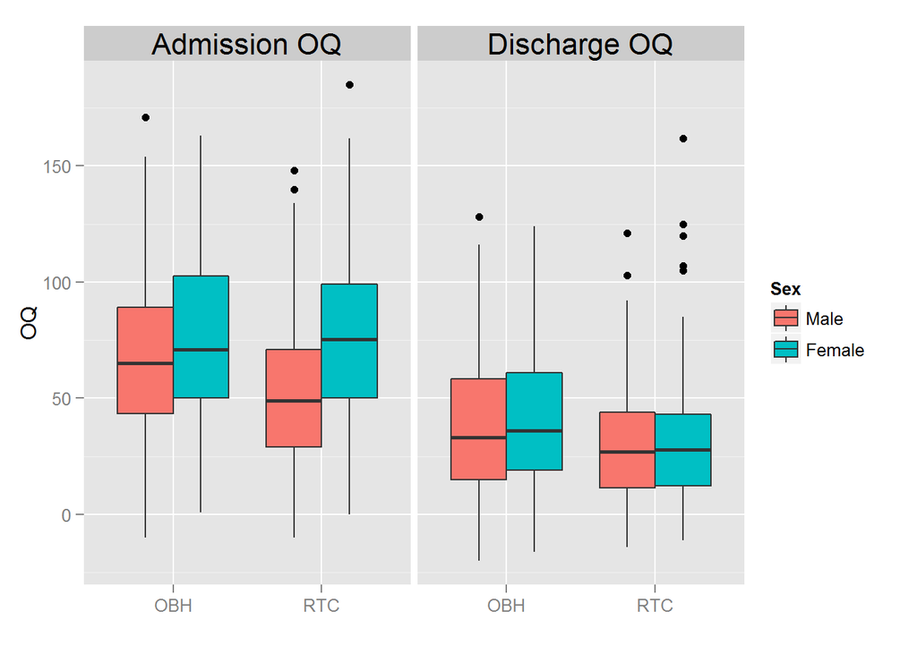

```r
OQ_adm_dis <- OQ %>%
    gather(adm_dis, OQ, admission_OQ, discharge_OQ)
levels(OQ_adm_dis$adm_dis)[levels(OQ_adm_dis$adm_dis) == "admission_OQ"] <-
    "Admission OQ"
levels(OQ_adm_dis$adm_dis)[levels(OQ_adm_dis$adm_dis) == "discharge_OQ"] <-
    "Discharge OQ"

plot_OQ_adm_dis <- ggplot(OQ_adm_dis, aes(x = RTC_OBH_full,
               y = OQ,
               fill = sex)) +
    geom_boxplot() +
    facet_grid(. ~ adm_dis) +
    xlab("") +
    scale_fill_discrete(name="Sex") +
    theme(strip.text.x = element_text(size=16))
plot_OQ_adm_dis
```

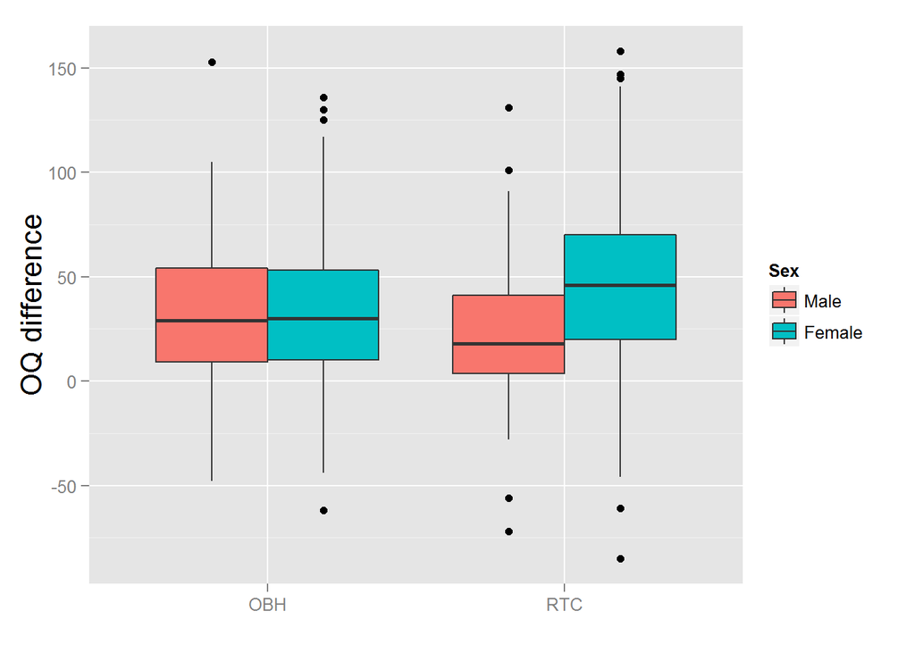

```r
plot_OQ_diff <- ggplot(OQ, aes(x = RTC_OBH_full, y = diff, fill = sex)) +
    geom_boxplot() +
    xlab("") +
    ylab("OQ difference") +
    scale_fill_discrete(name="Sex") +
    theme(axis.title.y = element_text(size=16))
plot_OQ_diff
```

That was for only `natsap_tidy`. Does this look different for the whole NATSAP database?

```r
OQ2 <- natsap %>%
    dplyr::select(ID = NatsapId,
           sex = GenderNumeric,
           admission_OQ = AdmissionTotalScore,
           discharge_OQ = DischargeTotalScore,
           RTC_OBH = RTCvsOBH) %>%
    mutate(diff = admission_OQ - discharge_OQ)


OQ2 <- OQ2[complete.cases(OQ2),]

## Make factor variable and relevel

OQ2 <- OQ2 %>%
    mutate(sex = as.factor(sex))

## Recode 0/1 as "male" and "female"
levels(OQ2$sex)[levels(OQ2$sex) == 0] <- "Male"
levels(OQ2$sex)[levels(OQ2$sex) == 1] <- "Female"


OQ_summary2 <- OQ2 %>%
    group_by(RTC_OBH, sex) %>%
    summarize(median(admission_OQ), median(discharge_OQ), median(diff))
OQ_summary2
```

```
## Source: local data frame [4 x 5]
## Groups: RTC_OBH
##
##   RTC_OBH    sex median(admission_OQ) median(discharge_OQ) median(diff)
## 1     OBH   Male                   63                 31.5           30
## 2     OBH Female                   72                 37.0           31
## 3     RTC   Male                   46                 27.0           15
## 4     RTC Female                   70                 29.0           41
```

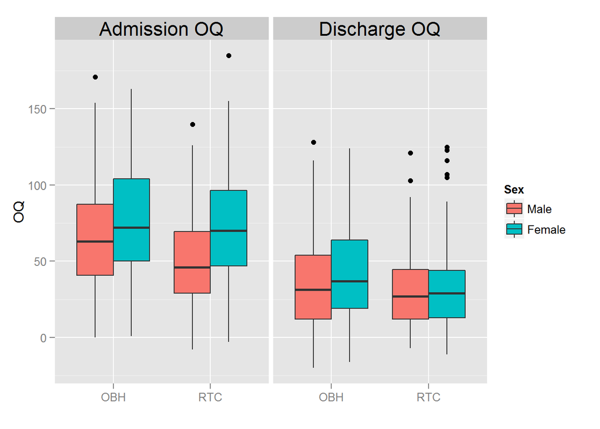

```r
OQ_adm_dis2 <- OQ2 %>%
    gather(adm_dis, OQ, admission_OQ, discharge_OQ)
levels(OQ_adm_dis2$adm_dis)[levels(OQ_adm_dis2$adm_dis) == "admission_OQ"] <-
    "Admission OQ"
levels(OQ_adm_dis2$adm_dis)[levels(OQ_adm_dis2$adm_dis) == "discharge_OQ"] <-
    "Discharge OQ"

ggplot(OQ_adm_dis2, aes(x = RTC_OBH,
               y = OQ,
               fill = sex)) +
    geom_boxplot() +
    facet_grid(. ~ adm_dis) +
    xlab("") +
    scale_fill_discrete(name="Sex") +
    theme(strip.text.x = element_text(size=16))
```

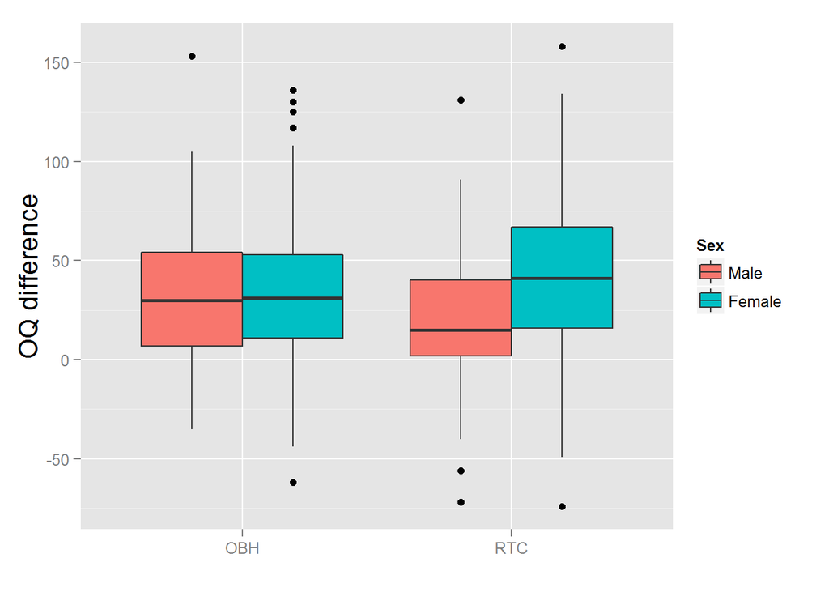

```r
ggplot(OQ2, aes(x = RTC_OBH, y = diff, fill = sex)) +
    geom_boxplot() +
    xlab("") +
    ylab("OQ difference") +
    scale_fill_discrete(name="Sex") +
    theme(axis.title.y = element_text(size=16))
```

## Dose data

```r
dose_tidy %>%
    dplyr::select(RTC_OBH, IT, GT, RFT) %>%
    arrange(RTC_OBH, IT, GT, RFT)
```

```
##    RTC_OBH  IT  GT    RFT
## 1      OBH  60   0   0.00
## 2      OBH  60  90   0.00
## 3      OBH  90  90   8.65
## 4      OBH  90 120   0.00
## 5      OBH  90 120   4.50
## 6      RTC  60 120  60.00
## 7      RTC  60 180  60.00
## 8      RTC  60 270  90.00
## 9      RTC  60 360  60.00
## 10     RTC  60 600  60.00
## 11     RTC  90 240  90.00
## 12     RTC  90 270  90.00
## 13     RTC  90 810  90.00
## 14     RTC 120 180  60.00
## 15     RTC 120 420 120.00
## 16     RTC 120 480  60.00
```

## Clean up plots for presentation

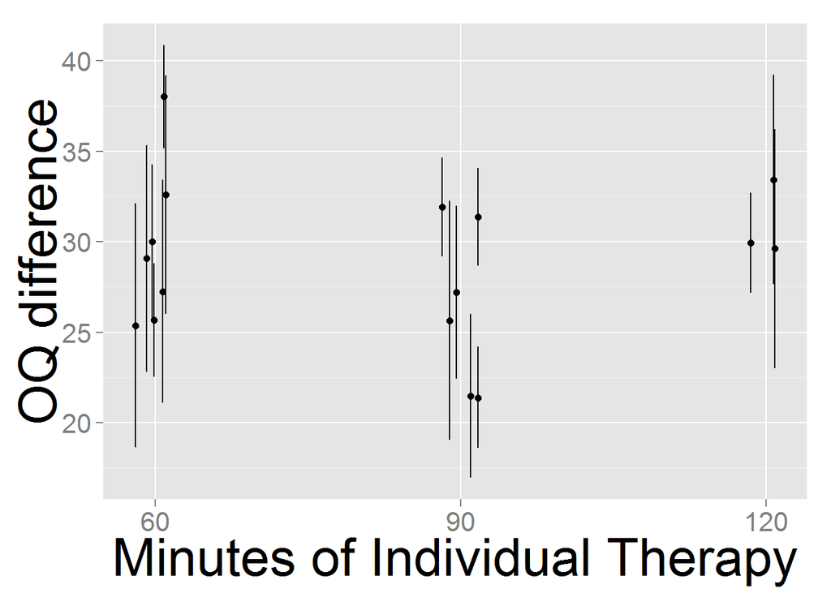

```r
plot_IT2 <- plot_IT2 +
    xlab("Minutes of Individual Therapy") +
    ylab("OQ difference") +
    theme(axis.title.x = element_text(size=32),
          axis.text.x  = element_text(size=16)) +
    theme(axis.title.y = element_text(size=32),
          axis.text.y  = element_text(size=16)) +
    scale_x_continuous(breaks = seq(60, 120, 30), minor_breaks = NULL)
plot_IT2
```

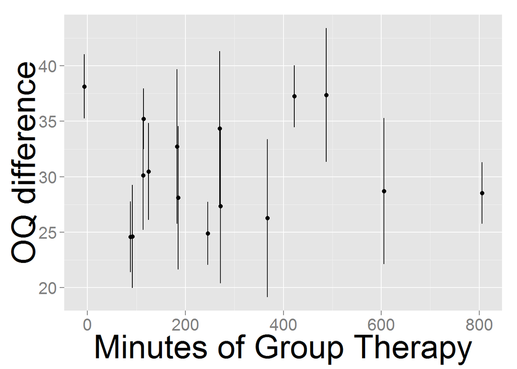

```r
plot_GT2 <- plot_GT2 +
    xlab("Minutes of Group Therapy") +
    ylab("OQ difference") +
    theme(axis.title.x = element_text(size=32),
          axis.text.x  = element_text(size=16)) +
    theme(axis.title.y = element_text(size=32),
          axis.text.y  = element_text(size=16))
plot_GT2
```

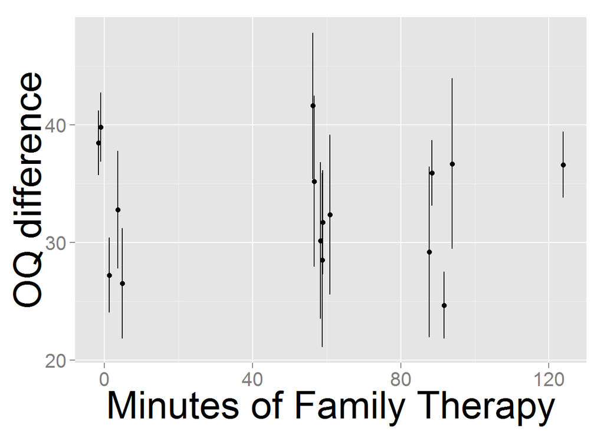

```r
plot_RFT2 <- plot_RFT2 +
    xlab("Minutes of Family Therapy") +
    ylab("OQ difference") +
    theme(axis.title.x = element_text(size=32),
          axis.text.x  = element_text(size=16)) +
    theme(axis.title.y = element_text(size=32),
          axis.text.y  = element_text(size=16))
plot_RFT2
```

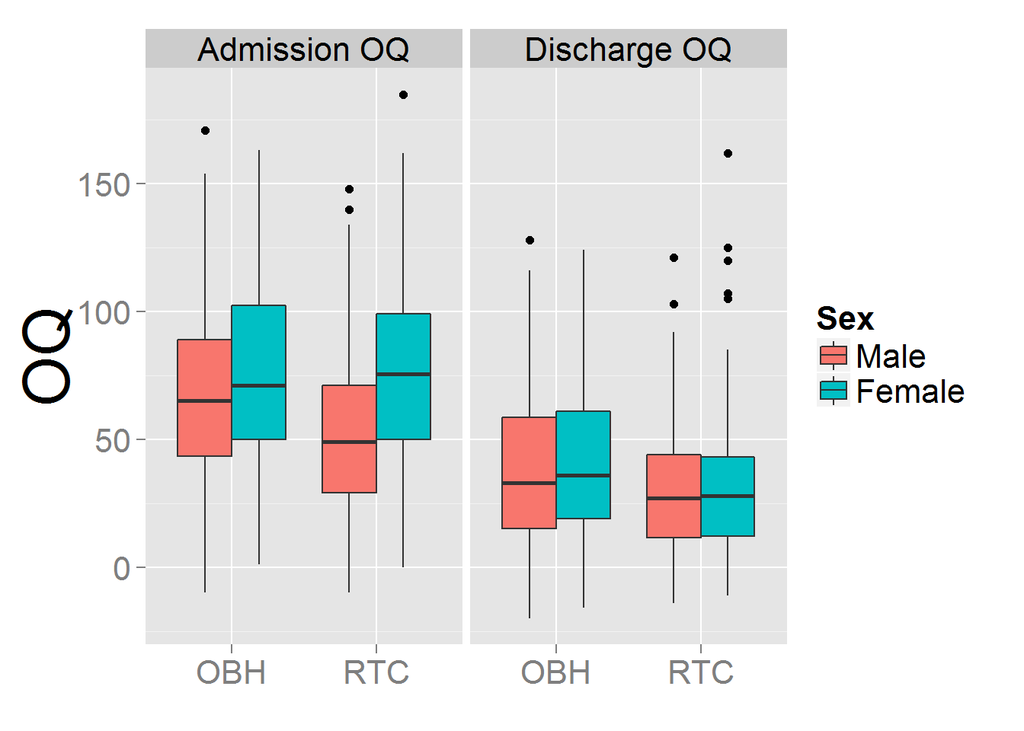

```r
plot_OQ_adm_dis <- ggplot(OQ_adm_dis, aes(x = RTC_OBH_full,
               y = OQ,
               fill = sex)) +
    geom_boxplot() +
    facet_grid(. ~ adm_dis) +
    xlab("") +
    scale_fill_discrete(name="Sex") +
    theme(strip.text.x = element_text(size=16),
          axis.text.x = element_text(size=16)) +
    theme(axis.title.y = element_text(size=32),
          axis.text.y  = element_text(size=16)) +
    theme(legend.title = element_text(size=16),
          legend.text = element_text(size=16))
plot_OQ_adm_dis
```

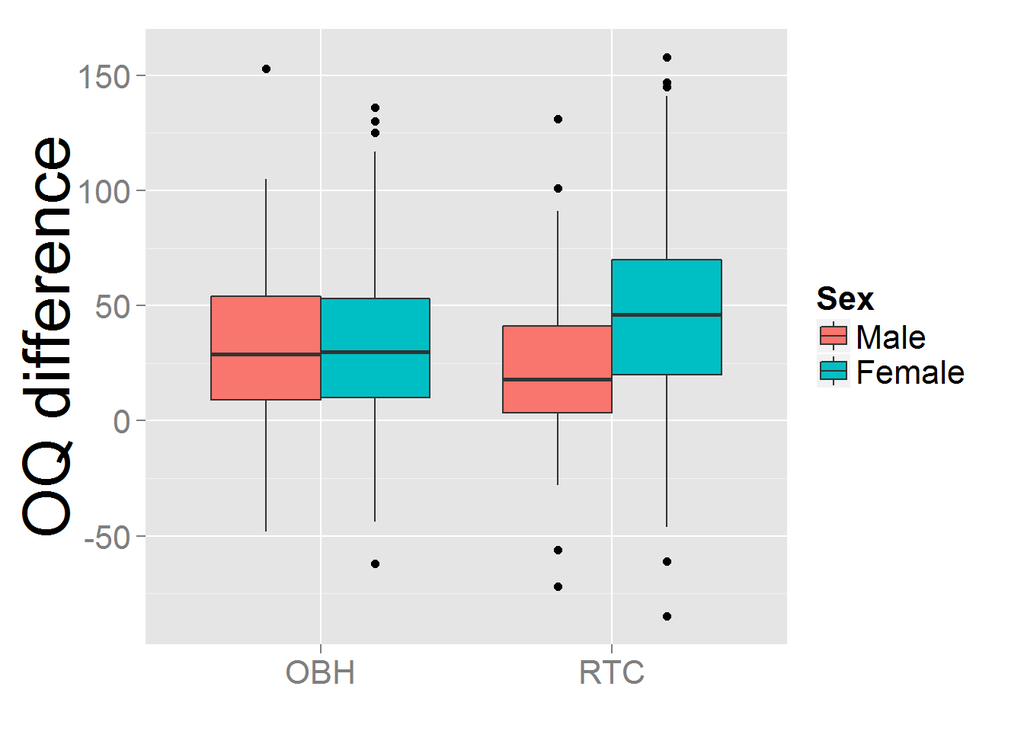

```r
plot_OQ_diff <- ggplot(OQ, aes(x = RTC_OBH_full, y = diff, fill = sex)) +
    geom_boxplot() +
    xlab("") +
    ylab("OQ difference") +
    scale_fill_discrete(name="Sex") +
    theme(axis.text.x = element_text(size=16)) +
    theme(axis.title.y = element_text(size=32),
          axis.text.y = element_text(size=16)) +
    theme(legend.title = element_text(size=16),
          legend.text = element_text(size=16))
plot_OQ_diff
```

## Plotting intercepts against group regression line

We correct the hierarchical plots: this time, rather than just showing the intercept, we need to add each group’s contribution to the variable of interest (IT, FT, RTC.)

```r
## Remove mean-centering for graphic purposes.

IT_full_uncentered <- IT[natsap_tidy$new_ID,]
fit_hier_vint_IT2_uncentered <- lmer(diff ~ sex + RTC_OBH_full + IT_full_uncentered +
                                    (1 | new_ID),
    data = natsap_tidy)
summary(fit_hier_vint_IT2_uncentered)
```

```
## Linear mixed model fit by REML ['lmerMod']
## Formula: diff ~ sex + RTC_OBH_full + IT_full_uncentered + (1 | new_ID)
##    Data: natsap_tidy
##
## REML criterion at convergence: 8537.9
##
## Scaled residuals:
##     Min      1Q  Median      3Q     Max
## -3.7714 -0.6647 -0.0751  0.6619  3.8813
##
## Random effects:
##  Groups   Name        Variance Std.Dev.
##  new_ID   (Intercept)   49.05   7.004
##  Residual             1158.79  34.041
## Number of obs: 863, groups:  new_ID, 16
##
## Fixed effects:
##                    Estimate Std. Error t value
## (Intercept)         11.1225    10.3452   1.075
## sexFemale            9.6823     3.1964   3.029
## RTC_OBH_fullRTC      0.1591     5.3460   0.030
## IT_full_uncentered   0.2137     0.1264   1.691
##
## Correlation of Fixed Effects:
##             (Intr) sexFml RTC_OB
## sexFemale   -0.050
## RTC_OBH_RTC  0.064 -0.143
## IT_fll_ncnt -0.930 -0.041 -0.319
```

```r
coef(fit_hier_vint_IT2_uncentered)
```

```
## $new_ID
##    (Intercept) sexFemale RTC_OBH_fullRTC IT_full_uncentered
## 1    12.301731  9.682272       0.1591436          0.2137251
## 2    20.392139  9.682272       0.1591436          0.2137251
## 3     3.758571  9.682272       0.1591436          0.2137251
## 4    14.977459  9.682272       0.1591436          0.2137251
## 5    14.303684  9.682272       0.1591436          0.2137251
## 6    12.377936  9.682272       0.1591436          0.2137251
## 7     3.859480  9.682272       0.1591436          0.2137251
## 8    11.994360  9.682272       0.1591436          0.2137251
## 9     8.020151  9.682272       0.1591436          0.2137251
## 10    7.743866  9.682272       0.1591436          0.2137251
## 11    9.568697  9.682272       0.1591436          0.2137251
## 12    9.617115  9.682272       0.1591436          0.2137251
## 13   11.438722  9.682272       0.1591436          0.2137251
## 14   15.813364  9.682272       0.1591436          0.2137251
## 15   13.739917  9.682272       0.1591436          0.2137251
## 16    8.052022  9.682272       0.1591436          0.2137251
##
## attr(,"class")
## [1] "coef.mer"
```

```r
fixef(fit_hier_vint_IT2_uncentered)
```

```
##        (Intercept)          sexFemale    RTC_OBH_fullRTC
##         11.1224509          9.6822723          0.1591436
## IT_full_uncentered
##          0.2137251
```

```r
ranef(fit_hier_vint_IT2_uncentered)
```

```
## $new_ID
##    (Intercept)
## 1    1.1792804
## 2    9.2696877
## 3   -7.3638802
## 4    3.8550077
## 5    3.1812333
## 6    1.2554850
## 7   -7.2629709
## 8    0.8719088
## 9   -3.1022999
## 10  -3.3785845
## 11  -1.5537539
## 12  -1.5053355
## 13   0.3162715
## 14   4.6909134
## 15   2.6174664
## 16  -3.0704293
```

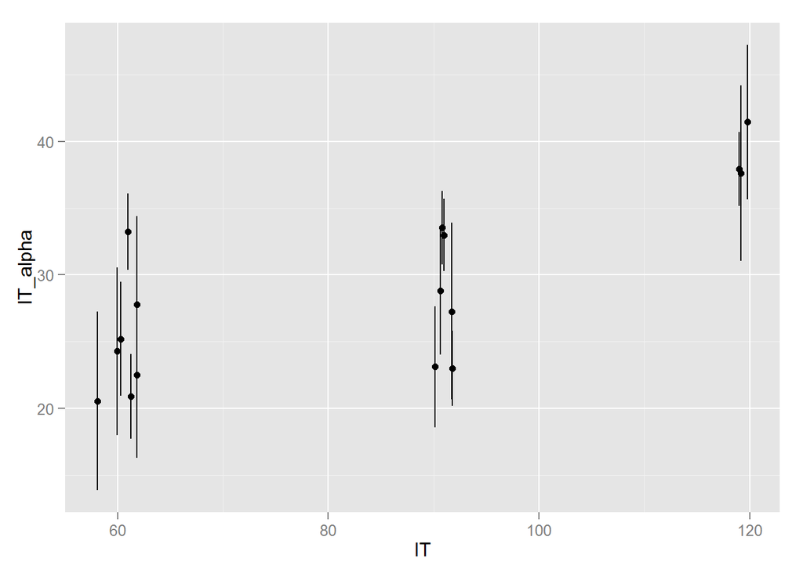

```r
## Extract coefficients for minutes of individual therapy.
## Plot corrected graph. (Earlier graphs failed to adjust the
## intercept for the group predictor.)

int_IT2_uncentered <- coef(fit_hier_vint_IT2_uncentered)$new_ID[,1]
se_int_IT2_uncentered <- se.ranef(fit_hier_vint_IT2_uncentered)$new_ID[,1]
IT_coef_uncentered <- fixef(fit_hier_vint_IT2_uncentered)['IT_full_uncentered']
int_by_IT2_corrected <-
    data.frame(dose_tidy$new_ID, IT = IT$IT, IT_alpha = int_IT2_uncentered + IT_coef_uncentered*IT$IT, se_int_IT2_uncentered)
limits_ind2_corrected <- aes(ymax = int_IT2_uncentered + IT_coef_uncentered*IT + se_int_IT2_uncentered, ymin = int_IT2_uncentered + IT_coef_uncentered*IT - se_int_IT2_uncentered)
plot_IT2_corrected <- ggplot(int_by_IT2_corrected, aes(x = IT, y = IT_alpha)) +
    geom_pointrange(limits_ind2_corrected, position = position_jitter(width = 2))
## The next command adds a fit line, but this is misleading as
## the slope is not significant.
#plot_IT2_corrected <- plot_IT2_corrected +
#    geom_abline(intercept = fixef(fit_hier_vint_IT2_uncentered)[1],
#                slope = fixef(fit_hier_vint_IT2_uncentered)[4])
plot_IT2_corrected
```

Go to the `NATSAP_2015` folder for the rest of the corrected analysis.